# MortaliTeach - build_log

Debasrija

2026-05-03

## Step 1 - Data and personas

## Why this project exists

Life and Health insurance pricing is built on this question: given everything we know about a person, how likely are they to cost us money? The Experience Study is the feedback loop that tells an insurer whether their answer to that question was right.

This project builds a tool that teaches that feedback loop from first principles, from a single scatter plot to a renegotiated reinsurance treaty, using real data and production-grade R engineering.

## What this project teaches

A person who completes this app will understand how insurance premiums are derived from observed data, how a life insurance pool works, what an Experience Study measures, why count A/E and amount A/E can tell different stories, and why reinsurers exist.

## Why this dataset specifically

### What the data is

1,338 real US health insurance records. Age, sex, BMI, smoking status, number of children, region, and actual charges billed.

Used to answer: what drives premium differences?

### What I found

- 1,338 rows, 7 columns, no missing values
- Charges: min $1,122, median $9,382, mean $13,270, max $63,770
- Right-skewed, so a small number of very expensive cases pull the mean up
- Age range 18–64
- Approximately equal male-female split, 662 female and 676 male

### What causes the difference in premiums?

One thing that affects premiums significantly is age. Premiums generally go up with age as they are considered higher risk in terms of both life and health.

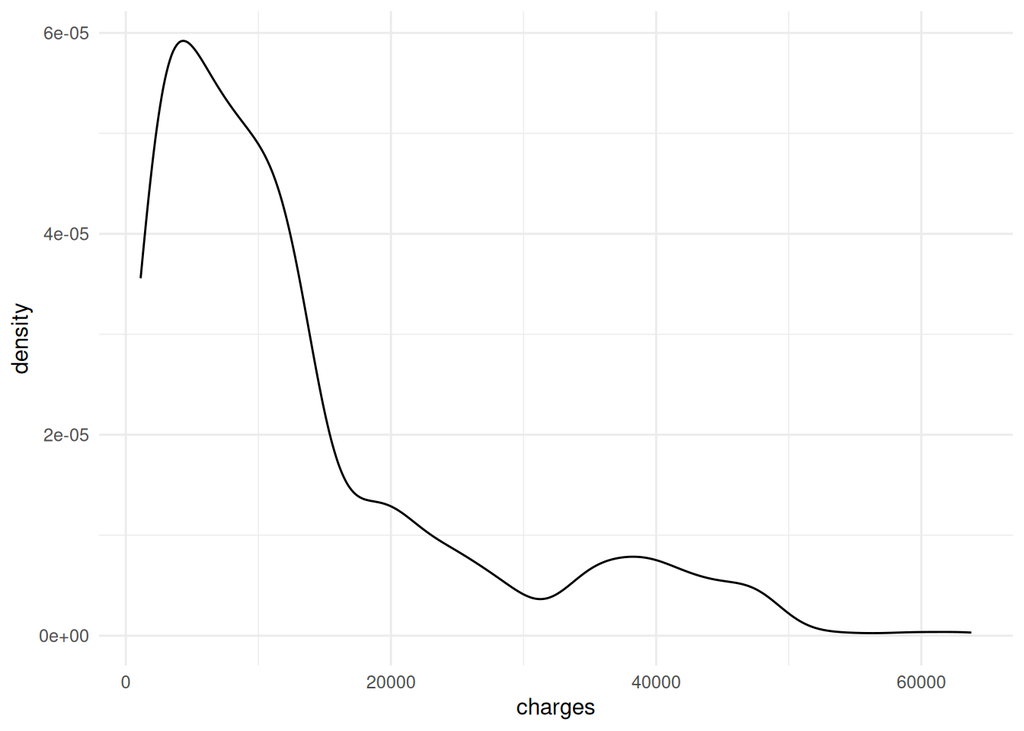

```r
ggplot(data = insurance) + geom_density(aes(x = charges)) + theme_minimal()
```

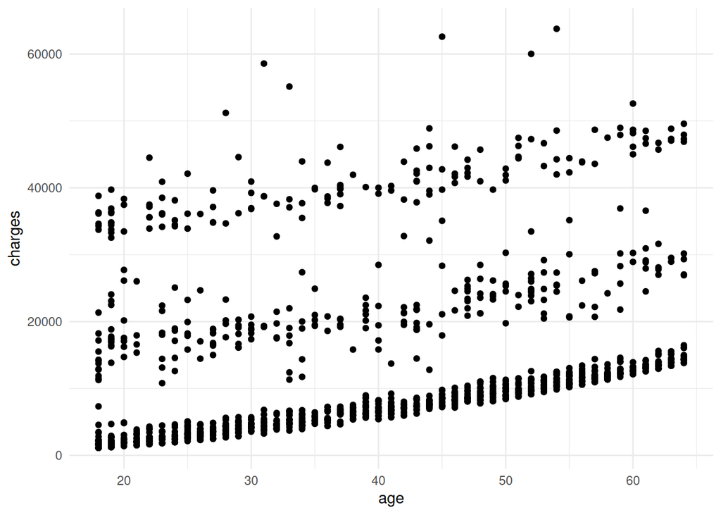

```r
ggplot(data = insurance) + geom_point(aes(x = age, y = charges)) + theme_minimal()
```

Interestingly - while the general trend of premiums going up holds, there are 3 bands, which means there is/are some other factor/factors behind the trend, not just age.

#### Smoker split

Based on background reading, I also knew that insurance premiums vary widely depending on whether the customer is a smoker or not, as it affects the mortality measures. So, I decided to start with that.

- There are 274 (20.48%) smokers and 1064 non-smokers. No missing values.
- Mean charges among smokers is $32050.23 and non-smokers is $8434.27, around 3.8x.

Hence, 1,338 real insurance premiums show that smokers pay nearly 3.8 times the premium as compared to a non-smoker.

#### Split by smoking status

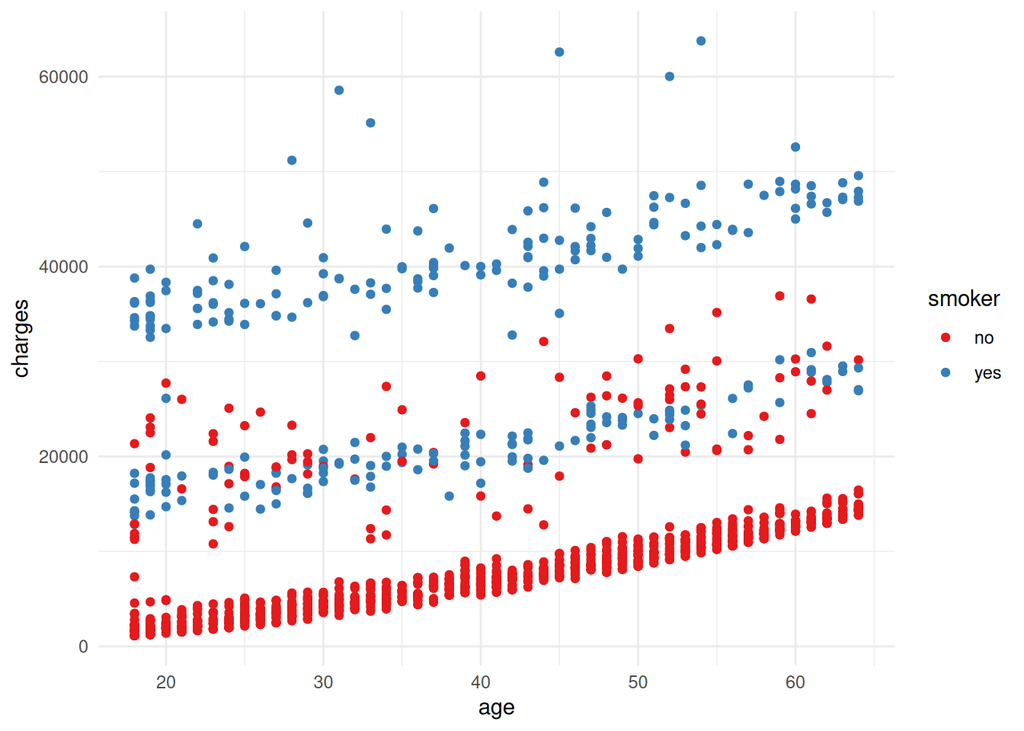

```r
ggplot(data = insurance) + geom_point(aes(x = age, y = charges, colour = smoker)) +
  scale_color_brewer(palette = "Set1") + theme_minimal()
```

The gap seems partially resolved. The top and bottom bands are composed entirely of smokers and non-smokers, but the middle band is a mixture. There may be other factors which have not been accounted for yet.

#### Split by smoking and obesity status

Another possible split might be BMI (obese/non-obese). Obesity and other comorbidities push premiums high up significantly as well.

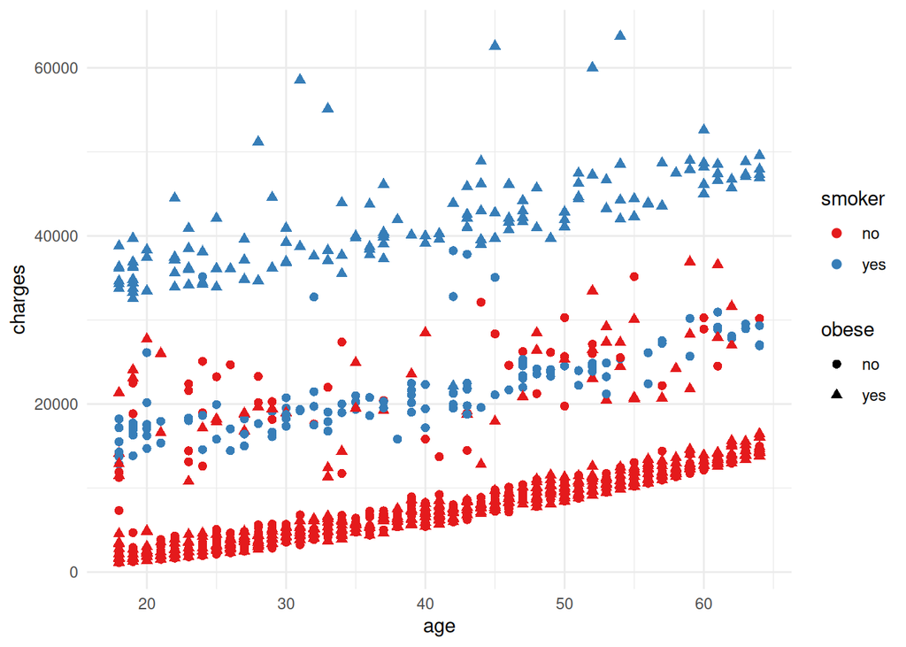

```r
insurance$obese[insurance$bmi >= 30] = "yes"
insurance$obese[insurance$bmi < 30] = "no"

ggplot(data = insurance) + geom_point(aes(x = age, y = charges, colour = smoker, shape = obese), size = 2) +
  scale_color_brewer(palette = "Set1") + theme_minimal()
```

Adding obesity (BMI >= 30) as shape resolves the remaining structure. Four groups are now visible:

### The four groups

Breaking down by both smoking status and obesity (BMI >= 30):

| Group | Mean charges |
| --- | --- |
| Smoker + obese | $41,558 |
| Smoker + non-obese | $21,363 |
| Non-smoker + obese | $8,843 |
| Non-smoker + non-obese | $7,977 |

Two things stand out immediately:

**Smoking dominates obesity.** A smoker with normal BMI ($21,363) costs more than twice a non-smoker who is obese ($8,843). The smoking effect overwhelms the BMI effect.

**Obesity matters much more when combined with smoking.** The obese/non-obese ratio among smokers is 1.95x ($41,558 vs $21,363). Among non-smokers it is only 1.11x ($8,843 vs $7,977). Obesity and smoking interact - they are not simply additive.

These four groups map to risk classes as follows:

- Non-smoker + non-obese - Preferred Elite
- Non-smoker + obese - Preferred
- Smoker + non-obese - Substandard
- Smoker + obese - Substandard (higher loading)

Smoking alone is disqualifying for Standard or better in real underwriting. Both smoker groups sit in Substandard. The obesity factor makes the combined group more expensive but does not change the classification tier: it changes the premium multiplier within that tier.

I can build a decision tree with this information, grouping subjects into further groups depending on whether this exploration missed any other factors.

So, this mapping may be potentially revised when the decision tree is fitted. The tree may suggest different natural groupings.

The first iteration of the decision tree is here -

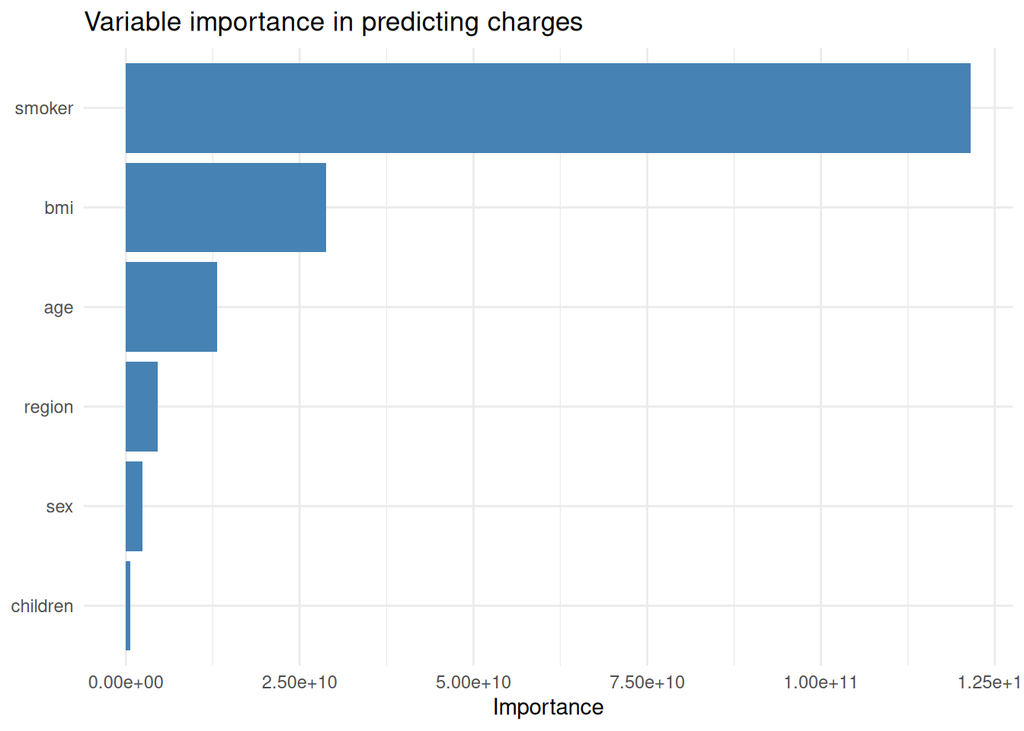

```r
library(rpart)
library(rpart.plot)

insurance$smoker <- as.factor(insurance$smoker)
insurance$sex    <- as.factor(insurance$sex)
insurance$region <- as.factor(insurance$region)

tree <- rpart(charges ~ age + bmi + smoker + sex + children + region,
              data = insurance,
              method = "anova")

importance <- as.data.frame(tree$variable.importance)
importance$variable <- rownames(importance)
colnames(importance)[1] <- "importance"

ggplot(importance, aes(x = reorder(variable, importance),
                       y = importance)) +
  geom_col(fill = "steelblue") +
  coord_flip() +
  labs(title = "Variable importance in predicting charges",
       x = NULL, y = "Importance") +
  theme_minimal()
```

This shows that smoking status, BMI and age are the three main factors behind the split in charges. I did not add obese as a dichotomous variable since I wanted to see where the split naturally happens given the dataset. (Note for self: charges is a continuous outcome variable, so the method used was ANOVA.)

```r
printcp(tree)
```

```
##
## Regression tree:
## rpart(formula = charges ~ age + bmi + smoker + sex + children +
##     region, data = insurance, method = "anova")
##
## Variables actually used in tree construction:
## [1] age    bmi    smoker
##
## Root node error: 1.9607e+11/1338 = 146542766
##
## n= 1338
##
##         CP nsplit rel error  xerror     xstd
## 1 0.619765      0   1.00000 1.00150 0.051905
## 2 0.143925      1   0.38024 0.38152 0.018922
## 3 0.063674      2   0.23631 0.23963 0.014538
## 4 0.010000      3   0.17264 0.17830 0.013269
```

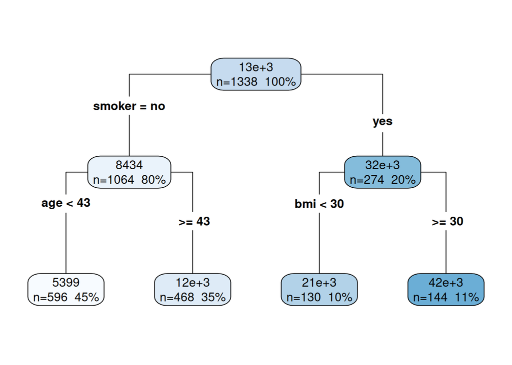

```r
rpart.plot(tree, type = 4, extra = 101, roundint = FALSE)
```

Within non-smokers, age is more discriminating than obesity at this level of the tree. The younger non-smokers average $5,399, older ones $12,000. Within smokers, the dominant factor becomes obesity, with the premiums being higher than non-smokers all around, non-obese individuals averaging $21,000 and obese averaging $42,000.

Another interesting thing is that the BMI categorisation for smokers does happen at the exact thresholds where obesity is defined. This serves as an extra sanity check as to whether the thresholds used earlier were correct given the dataset.

#### Why sex, region, and children were not used

In real insurance underwriting, sex does affect pricing (women generally have lower mortality than men). The fact that it does not appear here is likely because this is a health insurance charges dataset, not a life insurance mortality dataset.

The next thing to do now is to pick one representative persona for each of these groups. I decided to pick the individuals closest to the mean.

```r
insurance$leaf <- tree$where

leaf_means <- aggregate(charges ~ leaf, data = insurance,
                        FUN = mean)

personas <- do.call(rbind, lapply(unique(insurance$leaf), function(l) {
  group <- insurance[insurance$leaf == l, ]
  leaf_mean <- leaf_means$charges[leaf_means$leaf == l]
  closest <- which.min(abs(group$charges - leaf_mean))
  group[closest, ]
}))

print(personas)
```

```
##      age    sex   bmi children smoker    region   charges obese leaf
## 161   42 female 26.60        0    yes northwest 21348.706    no    6
## 524   38 female 37.73        0     no southeast  5397.617   yes    3
## 842   59   male 24.70        0     no northeast 12323.936    no    4
## 1091  47   male 36.19        0    yes southeast 41676.081   yes    7
```

These individuals are real ones picked from the dataset, and reduces the amount of ambiguity in deciding what characteristics should be present in these personas when designed.

Since I am planning to make an app, I will assign names to these individuals.

Now we give them names: (*wild Vampire Diaries reference appears*…)

- Row 524: **Elena** - 38, female, non-smoker, obese. Preferred Elite despite high BMI because she does not smoke and is under 43. Pays $5,398.
- Row 842: **Damon** - 59, male, non-smoker, normal BMI. Preferred as older age moves him out of Preferred Elite. Pays $12,324.
- Row 161: **Caroline** - 42, female, smoker, normal BMI. Substandard. Smoking alone puts her here regardless of normal BMI. Pays $21,349.
- Row 1091: **Niklaus** - 47, male, smoker, obese. Substandard high loading. Both risk factors present. Pays $41,676.

These four people will appear in every section of the app. Their numbers are real. Their names are not. Overall, the message here is that the premium order is driven almost entirely by smoking. This is not a biological truth, but is true for this dataset.

Making a dataframe for these 4 individuals.

```r
# VBT 2015 central death rates for the four personas
# Source: SOA Valuation Basic Table 2015
# mx = central death rate (deaths per person per year)

personas_vbt <- data.frame(
  name   = c("Elena", "Damon", "Caroline", "Niklaus"),
  age    = c(38, 59, 42, 47),
  sex    = c("female", "male", "female", "male"),
  smoker = c("no", "no", "yes", "yes"),
  bmi    = c(37.73, 24.70, 26.60, 36.19),
  health_charges = c(5397.617, 12323.936, 21348.706, 41676.081),
  risk_class = c("Preferred Elite", "Preferred",
                 "Substandard", "Substandard High"),
  stringsAsFactors = FALSE
)
```

ANB is used as the best approximation of age since it generally gives a more precise result.

From the 2015 VBT lookup table - we can get qx, and assuming uniform force of mortality, mx can be calculated.

```r
personas_vbt$qx <- c(
  0.00012, # Elena: F38NS
  0.00378, # Damon: M59NS
  0.00045, # Caroline: F42S
  0.00323 # Niklaus: M47S
)

personas_vbt$mx = -log(1 - personas_vbt$qx)

print(personas_vbt)
```

```
##       name age    sex smoker   bmi health_charges       risk_class      qx
## 1    Elena  38 female     no 37.73       5397.617  Preferred Elite 0.00012
## 2    Damon  59   male     no 24.70      12323.936        Preferred 0.00378
## 3 Caroline  42 female    yes 26.60      21348.706      Substandard 0.00045
## 4  Niklaus  47   male    yes 36.19      41676.081 Substandard High 0.00323
##             mx
## 1 0.0001200072
## 2 0.0037871623
## 3 0.0004501013
## 4 0.0032352277
```

Mortality vs charges ratio at similar ages should be consistent, in the same direction at least.

```r
# mortality ratio: smoker vs non-smoker at similar ages
cat("Caroline/Elena mortality ratio:",
    round(personas_vbt$mx[3] / personas_vbt$mx[1], 2), "\n")
```

```
## Caroline/Elena mortality ratio: 3.75
```

```r
cat("Health charges ratio (smoker/non-smoker):",
    round(21348 / 5397, 2), "\n")
```

```
## Health charges ratio (smoker/non-smoker): 3.96
```

Smoker/non-smoker mortality ratio (3.75x) is consistent with the health charges ratio from insurance data (3.96x). This confirms the bridge between the two datasets - the same variables that predict health costs predict mortality.

### Why a GLM alongside the decision tree

The decision tree showed us the risk classes visually. It is readable, intuitive, and derives groupings from data without any prior assumptions. But it has some weaknesses that make it unsuitable as a standalone model:

1. Small changes in the data can change the splits entirely.
2. The decision tree cannot adjust for factors like age and BMI between the smokers and non-smokers.
3. Age splits at exactly 43, but the true relationship between age and charges is continuous so it is not explainable fully.
4. No uncertainty estimates like standard errors, or confidence intervals.

### Why Gamma with log link

Charges are strictly positive and right-skewed. A standard linear regression (Gaussian GLM) would allow negative predicted values, which is impossible for insurance charges. The Gamma distribution respects the constraint that charges > 0 and matches the shape of the observed distribution.

The log link models multiplicative effects. A smoker does not pay a fixed dollar amount more than a non-smoker, they pay a multiple of what a non-smoker pays. The log link captures this correctly. It also means coefficients are directly interpretable as multipliers when exponentiated:

exp(coefficient) = charge multiplier for that variable

### Fitting the GLM

```r
glm_model <- glm(charges ~ age + bmi + smoker + sex +
                             children + region,
                 data = insurance,
                 family = Gamma(link = "log"))

summary(glm_model)
```

```
##
## Call:
## glm(formula = charges ~ age + bmi + smoker + sex + children +
##     region, family = Gamma(link = "log"), data = insurance)
##
## Coefficients:
##                  Estimate Std. Error t value Pr(>|t|)
## (Intercept)      7.386342   0.111350  66.334  < 2e-16 ***
## age              0.028638   0.001341  21.351  < 2e-16 ***
## bmi              0.014123   0.003224   4.381 1.28e-05 ***
## smokeryes        1.500330   0.046572  32.215  < 2e-16 ***
## sexmale         -0.057079   0.037531  -1.521  0.12854
## children         0.084173   0.015534   5.419 7.12e-08 ***
## regionnorthwest -0.057875   0.053687  -1.078  0.28123
## regionsoutheast -0.141637   0.053960  -2.625  0.00877 **
## regionsouthwest -0.145484   0.053874  -2.700  0.00701 **
## ---
## Signif. codes:  0 '***' 0.001 '**' 0.01 '*' 0.05 '.' 0.1 ' ' 1
##
## (Dispersion parameter for Gamma family taken to be 0.4669548)
##
##     Null deviance: 1056.04  on 1337  degrees of freedom
## Residual deviance:  337.73  on 1329  degrees of freedom
## AIC: 26379
##
## Number of Fisher Scoring iterations: 7
```

### Interpreting the coefficients

```r
exp(coef(glm_model))
```

```
##     (Intercept)             age             bmi       smokeryes         sexmale
##    1613.7920514       1.0290522       1.0142234       4.4831667       0.9445199
##        children regionnorthwest regionsoutheast regionsouthwest
##       1.0878173       0.9437681       0.8679361       0.8646040
```

The exponentiated coefficients are charge multipliers:

- `exp(intercept)` = baseline charge (female, non-smoker, age 0, BMI 0, no children, northeast region, not meaningful on its own but anchors the model)
- `exp(smokeryes)` = how many times more a smoker pays vs a non-smoker, holding everything else constant
- `exp(age)` = multiplier per additional year of age
- `exp(bmi)` = multiplier per additional BMI unit

### Observations

The smoker multiplier is 4.48, higher than what was observed in the data. Hence, the GLM is controlling for confounding between smoking and other variables (age, BMI) that the raw comparison, or the decision tree did not account for, because they are not equipped to do it. Once those are controlled for, smoking is even more expensive than the raw ratio suggested.

Age and BMI both have continuous significant effects (p < 0.001): 2.9% per year of age, 1.4% per BMI unit. The tree’s age threshold of 43 was thus a computational convenience.

Sex is not significant (p = 0.129) once other variables are controlled. However, it is known that men and women have significantly different mortalities. The absence of sex here is dataset-specific as this is not mortality data.

The GLM finds both children and region significant (p < 0.001, 8.8% per dependent, southeast and southwest significantly cheaper than northeast (~13-14%, p < 0.01)) but the tree ignored it entirely. This is not a contradiction.

The tree optimises variance reduction at each split. Both children and region have too few unique values to provide any discriminatory ability. The tree found the single best question that separates high vs low cost at a particular node. The GLM finds the marginal effect of each variable controlling for all others.

For my subsequent planned uses, the GLM is more usable because it uses all variables simultaneously and produces defensible coefficients.

#### Predicted charges for our personas

Once we have the GLM coefficients we can compute a predicted charge for each persona directly from the model.

```r
personas_vbt$predicted_charges <- predict(glm_model,
  newdata = data.frame(
    age      = personas_vbt$age,
    bmi      = personas_vbt$bmi,
    smoker   = personas_vbt$smoker,
    sex      = personas_vbt$sex,
    children = 0,
    region   = "northeast"
  ),
  type = "response")


personas_vbt$a_e_ratio = round(personas_vbt$health_charges/personas_vbt$predicted_charges, 3)

personas_vbt
```

```
##       name age    sex smoker   bmi health_charges       risk_class      qx
## 1    Elena  38 female     no 37.73       5397.617  Preferred Elite 0.00012
## 2    Damon  59   male     no 24.70      12323.936        Preferred 0.00378
## 3 Caroline  42 female    yes 26.60      21348.706      Substandard 0.00045
## 4  Niklaus  47   male    yes 36.19      41676.081 Substandard High 0.00323
##             mx predicted_charges a_e_ratio
## 1 0.0001200072          8163.766     0.661
## 2 0.0037871623         11704.866     1.053
## 3 0.0004501013         35071.796     0.609
## 4 0.0032352277         43770.099     0.952
```

This predicted charge becomes the basis for their life insurance premium in the next part planned: not the raw observed charge, but the model’s estimate of what someone with their risk profile should cost. Three of the four individuals cost less than expected, but what is interesting is that both the women have a significantly low A to E ratio.

Elena is obese, a factor that the DT did not consider, and put her into Preferred Elite (notably, the BMI factor was decisive only in the smoking branch in the DT). The GLM looks at the obesity status and predicts a higher premium.

Caroline is a non-obese smoker. The GLM applies the full smoking multiplier (4.48x) which may overstate costs for a lighter smoker with otherwise normal health indicators.

## But the predictions were not accurate…

The GLM’s predictions are based on average effects across all 1,338 people. Individual variation around those predictions is expected and normal. The A/E ratios here (0.61 to 1.05) show the range of individual variation for typical representatives of each risk class.

In a real experience study, we would aggregate these individual A/E ratios across thousands of people. The individual noise averages out. What remains is the signal showing whether the risk class was priced correctly on average.

The A/E ratios we got were per person, but for a proper actuarial study, one would scale up to many more individuals, follow them over a period of time and see how they fare over this period. To scale this up, I went for a modular approach that separates the analysis functions to make them testable in silo. This is the analytics engine that will come in this iteration.

## Part 2 - Analytics engine

### Scope

Functions to build: - `validate_cohort()` - hard failures on bad input data - `.load_nhanes()` - download and clean NHANES data - `load_cohort()` - public wrapper around `.load_nhanes()` (validates the cohort) - `build_exposure()` - expand cohort to person-year rows, needed format for the study - `attach_basis()` - join VBT mortality rates to exposure - `run_study()` - compute A/E

For this, I used the NHANES data.

### Dataset decision-why continuous NHANES 1999-2004

Used NHANES 1999-2004 (three waves combined).

```
Wave 1: ~5,000 adults, examined 1999-2000, up to 20yr follow-up
Wave 2: ~5,400 adults, examined 2001-2002, up to 18yr follow-up
Wave 3: ~5,000 adults, examined 2003-2004, up to 16yr follow-up
```

**Why continuous NHANES 1999-2004:** - nhanesA handles data retrieval cleanly - age, sex, smoking all available through one function call - Mortality linkage files parse correctly with the CDC fixed-width format recommended - Three waves give ~15,000 eligible adults with 16-20 years of follow-up-enough deaths for credible A/E ratios

**Tradeoffs:** - Basis mismatch: observed cohort 1999-2004 vs VBT 2015 expected rates-expected to show A/E near 1.0 or slight improvement due to mortality trends. However, this can be used to show if the basis is adequate. - This mismatch is itself a teaching moment-the experience study reveals whether the basis is adequate

### Why three waves specifically

Adding waves beyond 2003-2004 introduces changing smoking prevalence and mortality trends that complicate the teaching narrative without adding proportionate value.

### Data structure-two files per wave

The CDC splits participant information across two sources:

**Survey file** (nhanesA package): - DEMO has SEQN, RIDAGEYR (age in years), RIAGENDR (sex) - SMQ has SEQN, SMQ020 (ever smoked 100 cigarettes)

**Mortality linkage file** (CDC fixed-width - three files 1999-00, 2001-02, 2003-04): - SEQN, eligstat, mortstat, permth_exm (follow-up months)

Joined on SEQN. Neither file is complete alone.

### SMQ020 missingness investigation

After joining DEMO to SMQ for 1999-2000 wave: - 4,517 non-adults (age < 18): no SMQ020 - expected, smoking questionnaire not administered to children - 4,877 adults: have SMQ020 - 571 adults: missing SMQ020

Of the 571 missing adults: - 37 interviewed only, never examined, and so will not appear in mortality linkage file, drop out on join - 534 examined but no smoking status: almost entirely age 18-19, likely questionnaire age threshold issue

**Decision: exclude all participants with missing SMQ020.** No imputation as the smoker-distinct analysis requires known smoking status for every participant.

**Additional filter:** keep only examined participants (RIDSTATR == “Both Interviewed and MEC examined”) to ensure presence in mortality linkage file.

### validate_cohort() design and tests

Hard failures on six conditions. Returns df invisibly if all pass, stops with precise error message if any fail.

### Package dependencies — analytics.R

data.table requires library() for the [ operator — cannot be fully namespaced. One library() call at top of file. All other packages use explicit :: namespacing throughout.

Known technical debt: library(data.table) will be replaced with @import data.table in roxygen comments when converting to golem package in Iteration 4.

Dependencies: - data.table: exposure frame construction, keyed joins - readr: fixed-width mortality file parsing  
- nhanesA: NHANES survey data download - dplyr: cohort cleaning - tidyr: unnest in profiling version only

```r
source("R/analytics.R")

good <- data.frame(
  seqn            = 1L,
  age_at_exam     = 52L,
  sex             = "Male",
  smoker          = "non_smoker",
  vital_status    = 1L,
  follow_up_years = 8.7,
  stringsAsFactors = FALSE
)

validate_cohort(good)                    # passes silently

bad_age <- good; bad_age$age_at_exam <- 150L
tryCatch(validate_cohort(bad_age),
         error = function(e) message(e$message))
```

```
## Ages outside 18-85 at rows: 1
```

```r
bad_vs <- good; bad_vs$vital_status <- 9L
tryCatch(validate_cohort(bad_vs),
         error = function(e) message(e$message))
```

```
## vital_status must be 0 or 1. Bad rows: 1
```

```r
bad_sex <- good; bad_sex$sex <- "M"
tryCatch(validate_cohort(bad_sex),
         error = function(e) message(e$message))
```

```
## sex must be 'Male' or 'Female'. Bad rows: 1
```

```r
bad_fu <- good; bad_fu$follow_up_years <- -1
tryCatch(validate_cohort(bad_fu),
         error = function(e) message(e$message))
```

```
## Non-positive follow_up_years at rows: 1
```

```r
bad_na <- good; bad_na$age_at_exam <- NA
tryCatch(validate_cohort(bad_na),
         error = function(e) message(e$message))
```

```
## NAs found in column 'age_at_exam' at rows: 1
```

```r
bad_smoker <- good; bad_smoker$smoker <- "yes"
tryCatch(validate_cohort(bad_smoker),
         error = function(e) message(e$message))
```

```
## smoker must be 'smoker' or 'non_smoker'. Bad rows: 1
```

All six checks pass. Function complete.

### Why each check exists

**Missing columns:** downstream functions use column names directly-a missing column produces a cryptic error six functions deep. Better to fail at the door with a clear message.

**NAs in required columns:** NA in age_at_exam would produce NA rows in the exposure frame. NA in vital_status would corrupt the death count. NA in follow_up_years would produce NA exposure. All silent corruptions.

**Age 18-85:** NHANES exam ages cap at 85 in practice. Maximum attained age during follow-up is 104.5 years — the VBT 2015 covers this (goes to age 120). The 85 limit applies at entry only, not during follow-up.

**follow_up_years > 0:** Zero or negative follow-up produces zero or negative exposure rows. The conservation law test would still pass but the person contributes nothing to the study-they should not be in the cohort.

**vital_status in {0,1}:** Any other value means the linkage failed or the data was corrupted. 2, 7, 9 are common NHANES codes for refused/unknown-these must never be silently treated as alive or dead.

**sex in {Male, Female}:** attach_basis() joins on sex to get the correct VBT rate. Any other value produces NA ref_rate for that participant-the silent NA corruption that must never reach run_study().

### Cohort summary — load_cohort() output

```
14,170 participants — three waves combined
Female: 7,458 (52.6%)
Male:   6,712 (47.4%)
Non-smoker: 7,295 (51.5%)
Smoker:     6,875 (48.5%)
Deaths: 4,087 (28.8%)
Age at exam: median 48, range 20-85
Follow-up: median 16.8 years, max 20.75 years
```

We observed that out of the eligible ones, 48.5% are smokers. This is high compared to the ~20% in insurance.csv. This reflects two things, that NHANES 1999-2004 had higher smoking prevalence than current rates, and “ever smoked 100 cigarettes” includes former smokers who may have quit. Former smokers may have lower mortality than current smokers. The VBT smoker rates assume current smokers. This will likely push smoker A/E below 1.0.This will affect our A/E ratios and is worth documenting.

### profvis results — build_exposure_loop

Root cause confirmed: constructing one data.frame per participant inside the loop triggers 14,170 separate memory allocations. Each allocation increases GC pressure. The arithmetic (seq, rep, floor) is essentially free by comparison.

This is why dplyr rowwise() did not fix the problem — it also allocates per-row intermediates, just with cleaner syntax hiding the cost.

data.table fixes the root cause: rep() replicates the entire table in one allocation, then := mutates in-place with no copying. Zero per-row allocations.

Timings on 14,170 NHANES participants: - Loop: 4.76s - dplyr: 2.10s  
- data.table: 0.027s - Speedup: 176x (loop), 78x (dplyr)